# Module Five Activity

For the module five activity, you will write Python code to create clear and informative data visualizations from the provided data set `Most-Recent-Cohorts-Field-of-Study.csv`. Your code should be well-organized and reflect a clear understanding of each step in the visualization process.

*Note:* there are two parts to this assignment. Part One is the data visualization coding activity. Part Two is the reflection paper.

Once your code is complete, you will download this notebook as an HTML file by clicking **File**, then **Download As**, then **HTML (.html)** from the Jupyter menu bar. Validate that your code, output, and all six visualizations (rendered as images using the display() function) are visible in the html file before submission.

*Missing Blocks:* Ensure that you have clicked **Run** for all blocks before downloading as an HTML file or the block may be missing from your submission. **Images** must be called using the *display()* function, for example: **display(Image(filename="output/{image_name}.png"))**

Specifically, you must address the items from the rubric criteria.

### Part One: Data Visualization

#### Prepare the given data set for visualization. Consider the following:

- Are there any columns you can remove?
- Are filters or groupings needed?
- Are the data values structured for your chart types?

#### Clean the given data set for visualization using Python. Consider the following:

- Are there any missing or invalid values?
- Are there any unclear column names?
- Are the data types correct for each column (e.g., numeric, categorical, datetime)?

#### Create multiple types of visualizations using Python. Include the following:

- Dendrogram
- PCA scatterplot
- Cluster size distribution
- Feature importance heatmap
- Trend chart
- Scatterplot

*Note:* You will need to ensure that you have created at least one of each of the visual types listed above.

### Part 2: Reflection

*This part is to be completed in a word document, using the output here to answer the topics.*

#### Identify patterns in the data. Consider the following:

- Are there any clear trends, clusters, or outliers visible in your visualizations?
- Are certain variables showing consistent behavior or relationships?
- Are the patterns similar across different visualization types?

#### Draw conclusions from the patterns. Consider the following:

- Are your conclusions clearly based on the patterns you observed?
- Are your findings supported by multiple visuals or data points?

#### Explain how the visualizations validate your findings. Consider the following:

- Are specific chart elements (e.g., color, scale, labels) helping to highlight your findings?
- Are the insights you found something you could not easily see without the visuals?

#### Write a summary of the visualization choices you made. Include the following:

- An explanation of the types of charts you used
- An explanation of the formatting decisions to support visual clarity

*To Begin:* This Python template program has been broken down into segments as a guide for what steps you should do at a minimum to complete this activity. Look for the **# To Do:** comments. These are placeholders for you to provide Python code segments. Fill out all **# To Do:** code segments to complete this program.  
*Once Complete:* Execute a "Kernel restart and run all" to verify that all your code works as a single unit by clicking **Kernel**, then **Restart & Run All** before downloading as html.

*Hint:* If you need to install additional packages, see one of the earlier modules on how to configure and call a requirements.txt file.

## Import the Required Packages

- **pandas (pd):** For reading and manipulating the dataset.
- **MinMaxScaler:** A preprocessing tool from sklearn to normalize data values between 0 and 1.
- **PCA:** Principal Component Analysis (dimensionality reduction) from sklearn for visualizing clusters in 2D.
- **dendrogram, linkage, fcluster:** Tools from scipy for performing hierarchical clustering and visualizing its results.
- **matplotlib.pyplot (plt):** For creating charts and saving visuals.
- **seaborn (sns):** For advanced and visually appealing charts.
- **numpy (np):** For numerical operations like arrays and aggregations.

```python
import pandas as pd   # for reading & manipulating the dataset
from sklearn.preprocessing import MinMaxScaler    # a preprocessing tool from sklearn to normalize data values
                                                                                    # between 0 and 1
from sklearn.decomposition import PCA  # Principal Component Analysis (dimensionality reduction) from
                                                                   # sklearn for visualizing clusters in 2D
from scipy.cluster.hierarchy import dendrogram, linkage, fcluster    # tools from scipy for performing hierarchical clustering & visualizing its results
import matplotlib.pyplot as plt     #  for creating charts & saving visuals
import seaborn as sns    #  for advanced & visually appealing charts
import numpy as np      # for numerical operations like arrays & aggregations

from IPython.display import Image, display # for image rendering in html output
```

# Part One: Data Visualization

## Loading the Data

*Hints:* Use **pd.read_csv** to read a CSV file and load it into a DataFrame (data). Use **try block** to ensures the program handles errors gracefully if the file cannot be loaded (e.g., missing or incorrect path). Use **exit()** to stop the program if an error occurs.

```python
# use the given dataset named "Most-Recent-Cohorts-Field-of-Study.csv" for this assignment
# for secure coding, put this action in a try/catch block

try:
    print("Loading dataset...")
    data = pd.read_csv("data/Most-Recent-Cohorts-Field-of-Study.csv")
    print("\tDataset loaded!")
except Exception as exception:
    print(f"ERROR: Unable to load dataset: {exception}")
    # graceful exit if error occurs
    exit()
```

```
Loading dataset...
	Dataset loaded!
```

## Display Dataset Information

*Hints:* Use **data.columns.tolist()** to extract and print all column names. Use **data.index.tolist()** to show the index values of the dataset (e.g., row numbers). Use **data.head()** to display the top 5 rows to give an overview of the data.

```python
print("Displaying dataset information...")
print("\tColumn Names:")
# print all column names
len(data.columns.tolist())
```

```
Displaying dataset information...
	Column Names:
```

```
174
```

```python
print("\tRow Index Labels:")
# print first 20 row data labels, just numerical indices no need to print them all
data.index.tolist()[:20]
```

```
	Row Index Labels:
```

```
[0, 1, 2, 3, 4, 5, 6, 7, 8, 9, 10, 11, 12, 13, 14, 15, 16, 17, 18, 19]
```

```python
print("\tFirst 5 Rows of the Dataset:")
# print the first 5 rows of the dataset
data.head()
```

```
	First 5 Rows of the Dataset:
```

|  | UNITID | OPEID6 | INSTNM | CONTROL | MAIN | CIPCODE | CIPDESC | CREDLEV | CREDDESC | IPEDSCOUNT1 | ... | EARN_COUNT_PELL_WNE_5YR | EARN_PELL_WNE_MDN_5YR | EARN_COUNT_NOPELL_WNE_5YR | EARN_NOPELL_WNE_MDN_5YR | EARN_COUNT_MALE_WNE_5YR | EARN_MALE_WNE_MDN_5YR | EARN_COUNT_NOMALE_WNE_5YR | EARN_NOMALE_WNE_MDN_5YR | EARN_COUNT_HIGH_CRED_5YR | EARN_IN_STATE_5YR |
| --- | --- | --- | --- | --- | --- | --- | --- | --- | --- | --- | --- | --- | --- | --- | --- | --- | --- | --- | --- | --- | --- |
| 0 | 100654.0 | 1002 | Alabama A & M University | Public | 1 | 100 | Agriculture, General. | 3 | Bachelor's Degree | NaN | ... | PS | PS | PS | PS | PS | PS | PS | PS | PS | PS |
| 1 | 100654.0 | 1002 | Alabama A & M University | Public | 1 | 101 | Agricultural Business and Management. | 3 | Bachelor's Degree | NaN | ... | PS | PS | PS | PS | PS | PS | PS | PS | PS | PS |
| 2 | 100654.0 | 1002 | Alabama A & M University | Public | 1 | 109 | Animal Sciences. | 3 | Bachelor's Degree | 3.0 | ... | PS | PS | PS | PS | PS | PS | PS | PS | PS | PS |
| 3 | 100654.0 | 1002 | Alabama A & M University | Public | 1 | 110 | Food Science and Technology. | 3 | Bachelor's Degree | 7.0 | ... | PS | PS | PS | PS | PS | PS | PS | PS | PS | PS |
| 4 | 100654.0 | 1002 | Alabama A & M University | Public | 1 | 110 | Food Science and Technology. | 5 | Master's Degree | 4.0 | ... | PS | PS | PS | PS | PS | PS | PS | PS | PS | PS |

5 rows × 174 columns

## Inspect and Select Numeric Columns

*Hints:* Use **select_dtypes()** to filter columns with numeric data types (float64 and int64). Removes columns like **UNITID** and **OPEID6**, which are not useful for clustering. Use **dropna()** to remove rows with missing values to clean data for clustering, see also module three sample for additional cleaning examples. Use error handling **try blocks** to ensures the program stops if the column selection fails.

```python
print("Inspecting dataset to select numeric columns for clustering...")
# To Do: In a try/catch block, exclude identifiers 'UNITID' and 'OPEID6',
#        then print the numeric columns selected for clustering and also print the data for clustering in rows & columns

try:
    # exclude the UNITID and OPEID6 columns since they are unqiue ids and not useful for clustering
    print("\tRemoving UNITID and OPEID6 columns...")
    data.drop(["UNITID", "OPEID6"], axis=1, inplace=True)

    print("\tExtracting numeric columns...")
    numeric_columns = data.select_dtypes(include=["float64", "int64"])

    print("\tRemoving rows with missing values...")
    numeric_columns.dropna(inplace=True)
    print(f"\tRetained {numeric_columns.shape[0]} rows.")

    # rename columns for clarity
    numeric_columns = numeric_columns.rename(columns={
        'MAIN': 'Main/Branch Campus',
        'CIPCODE': 'Field of Study',
        'CREDLEV': 'Credential Level',
        'IPEDSCOUNT1': 'Awards Year 1',
        'IPEDSCOUNT2': 'Awards Year 2',
        'DISTANCE': 'In Person/Online'
    })
except Exception as exception:
    print(f"ERROR: Unable to select columns: {exception}")
    # graceful exit
    exit()

print("Numeric columns selected for a analysis:")
numeric_columns.columns.tolist()
```

```
Inspecting dataset to select numeric columns for clustering...
	Removing UNITID and OPEID6 columns...
	Extracting numeric columns...
	Removing rows with missing values...
	Retained 184861 rows.
Numeric columns selected for a analysis:
```

```
['Main/Branch Campus',
 'Field of Study',
 'Credential Level',
 'Awards Year 1',
 'Awards Year 2',
 'In Person/Online']
```

## Normalize the Data

*Hints:* Use **MinMaxScaler()** to scale data values between 0 and 1, ensuring all features are on the same scale. Use **fit_transform()** to fit the scaler to the data and transform it.

```python
print("Normalizing the data using MinMaxScaler...")
# To Do: in a try/catch block, normalize the data using MinMaxScaler

try:
    # default range is 0 to 1
    scaler = MinMaxScaler()
    scaled = pd.DataFrame(scaler.fit_transform(numeric_columns), columns=numeric_columns.columns)
except Exception as exception:
    print(f"ERROR: Unable to normalize data: {exception}")
    # graceful exit
    exit()

# display first 5 rows as a sanity check
scaled.head()
```

```
Normalizing the data using MinMaxScaler...
```

|  | Main/Branch Campus | Field of Study | Credential Level | Awards Year 1 | Awards Year 2 | In Person/Online |
| --- | --- | --- | --- | --- | --- | --- |
| 0 | 1.0 | 0.001698 | 0.285714 | 0.000330 | 0.000937 | 0.0 |
| 1 | 1.0 | 0.001886 | 0.285714 | 0.000771 | 0.001041 | 0.0 |
| 2 | 1.0 | 0.001886 | 0.571429 | 0.000440 | 0.000625 | 0.0 |
| 3 | 1.0 | 0.001886 | 0.714286 | 0.000220 | 0.000416 | 0.0 |
| 4 | 1.0 | 0.018676 | 0.285714 | 0.000661 | 0.000625 | 0.0 |

## Perform Hierarchical Clustering

*Hints:* Use **linkage()** to compute hierarchical clusters using **Ward's** method, which minimizes variance between clusters. Limit clustering to the first 1000 rows for performance. Use **fcluster()** to assign cluster labels to data points based on the number of clusters (max_clusters).

```python
print("Performing hierarchical clustering using Ward's method...")
# To Do: in a try/catch block use the Ward's method to perform hierarchical clustering, limit max clusters to 4.

try:
    # select only the first 1000 rows for clustering
    subset = scaled.iloc[:1000].copy()
    # compute hierarchical clustering using Ward's method (minmize variance)
    Z = linkage(subset, method='ward')
    max_clusters = 4

    # assign cluster labels to the data points
    # limit to 4 clusters
    subset['Cluster Label'] = fcluster(Z, t=max_clusters, criterion='maxclust')
except Exception as exception:
    print(f"ERROR: Unable to cluster data: {exception}")
    # graceful exit
    exit()

subset.head()
```

```
Performing hierarchical clustering using Ward's method...
```

|  | Main/Branch Campus | Field of Study | Credential Level | Awards Year 1 | Awards Year 2 | In Person/Online | Cluster Label |
| --- | --- | --- | --- | --- | --- | --- | --- |
| 0 | 1.0 | 0.001698 | 0.285714 | 0.000330 | 0.000937 | 0.0 | 4 |
| 1 | 1.0 | 0.001886 | 0.285714 | 0.000771 | 0.001041 | 0.0 | 4 |
| 2 | 1.0 | 0.001886 | 0.571429 | 0.000440 | 0.000625 | 0.0 | 3 |
| 3 | 1.0 | 0.001886 | 0.714286 | 0.000220 | 0.000416 | 0.0 | 3 |
| 4 | 1.0 | 0.018676 | 0.285714 | 0.000661 | 0.000625 | 0.0 | 4 |

## Generate, Save, and Output Visualizations

Each visualization is created, saved and displayed, with text output provided before and after.

### Dendrogram

*Hints:* A dendrogram displays the hierarchical structure of clusters. Save the image as **dendrogram.png**. Use **display()** to render the image for html file output. Do not use an html image tag in the markdown, or the image will not print in the html download.

```
Creating dendrogram to visualize hierarchical clustering...
```

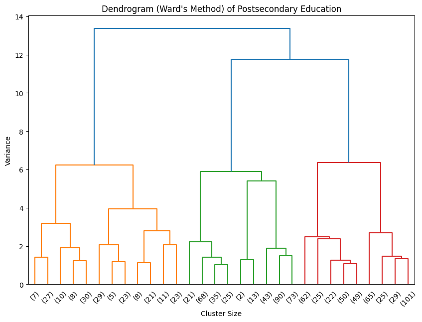

```python
print("Creating dendrogram to visualize hierarchical clustering...")
# To Do: Create a dendrogram to visualize hierarchical clustering, and save the dendrogram into a png file under the 'output' folder.

# figure set up
plt.figure(figsize=(10, 7))
plt.title("Dendrogram (Ward's Method) of Postsecondary Education")
plt.xlabel("Cluster Size")
plt.ylabel("Variance")

# plotting
dendrogram(
    Z,
    truncate_mode='lastp',
    p=30,
    show_leaf_counts=True
)

# save png
plt.savefig('output/dendrogram.png', bbox_inches='tight')
```

```
Dendrogram visualization display...
```

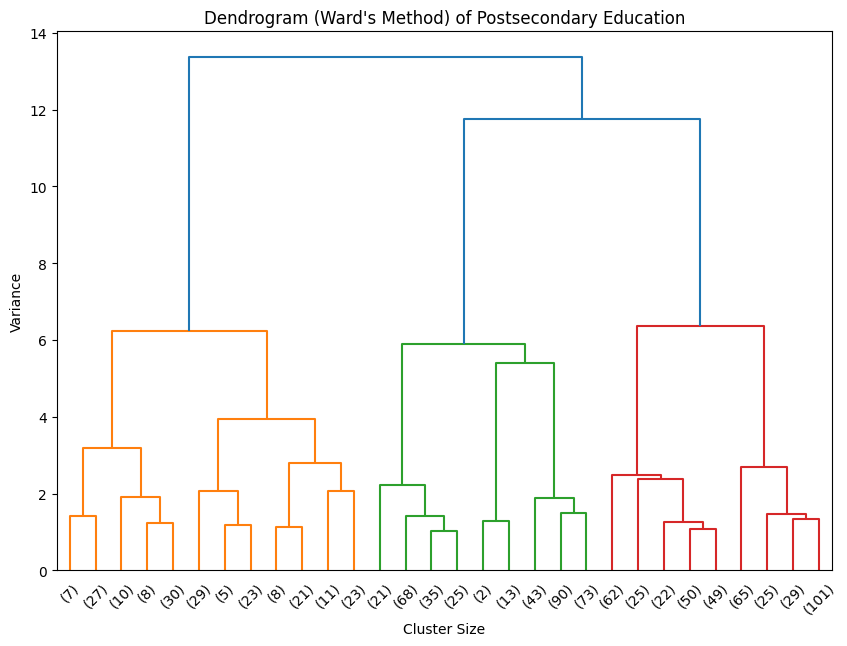

```python
print("Dendrogram visualization display...")
# To Do: output the image using the display() function, for example: display(Image(filename="output/scatter_plot.png"))
display(Image(filename='output/dendrogram.png'))
```

### PCA Scatter Plot

*Hints:* A PCA scatter plot projects high-dimensional data into 2D using PCA for visualization. Save the image as **pca_scatter_plot.png**. Use **display()** to render the image for html file output. Do not use an html image tag in the markdown, or the image will not print in the html download.

```
Creating scatter plot (PCA Reduced) to visualize clusters in 2D...
```

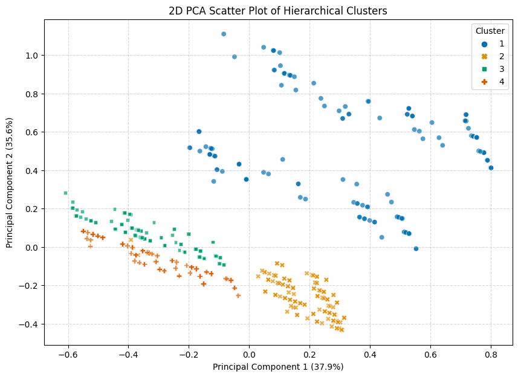

```python
print("Creating scatter plot (PCA Reduced) to visualize clusters in 2D...")
# To Do: Create a PCA Scatter Plot to visualize clusters in 2D, and save the PCA Scatter Plot into a png file under the 'output' folder.

# select only the first 1000 rows for visualization
features = scaled.iloc[:1000].copy()

# reduce to 2 components
pca = PCA(n_components=2)
pca_features = pca.fit_transform(features)

# plot with temporary dataframe
df_pca = pd.DataFrame(data=pca_features, columns=['PC1', 'PC2'])
df_pca['Cluster'] = subset['Cluster Label'].values

# plotting
plt.figure(figsize=(10, 7))
sns.scatterplot(
    x='PC1',
    y='PC2',
    hue='Cluster',
    style='Cluster',
    palette='colorblind',
    data=df_pca,
    alpha=0.7
)

plt.title('2D PCA Scatter Plot of Hierarchical Clusters')
plt.xlabel(f'Principal Component 1 ({pca.explained_variance_ratio_[0]:.1%})')
plt.ylabel(f'Principal Component 2 ({pca.explained_variance_ratio_[1]:.1%})')
plt.legend(title='Cluster', loc='best')
plt.grid(True, linestyle='--', alpha=0.5)

plt.savefig('output/pca_scatter_plot.png', bbox_inches='tight')
```

```
PCA scatter plot visualization display...
```

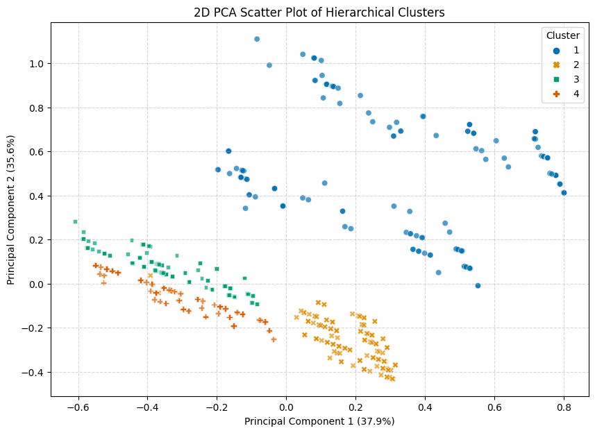

```python
print("PCA scatter plot visualization display...")
# To Do: output the image using the display() function, for example: display(Image(filename="output/pca_scatter_plot.png"))
display(Image(filename='output/pca_scatter_plot.png'))
```

### Cluster Size Distribution

*Hints:* A cluster size distribution displays the population size of each cluster. Save the image as **cluster_size.png**. Use **display()** to render the image for html file output. Do not use an html image tag in the markdown, or the image will not print in the html download.

```
Creating cluster size distribution chart to analyze cluster populations...
```

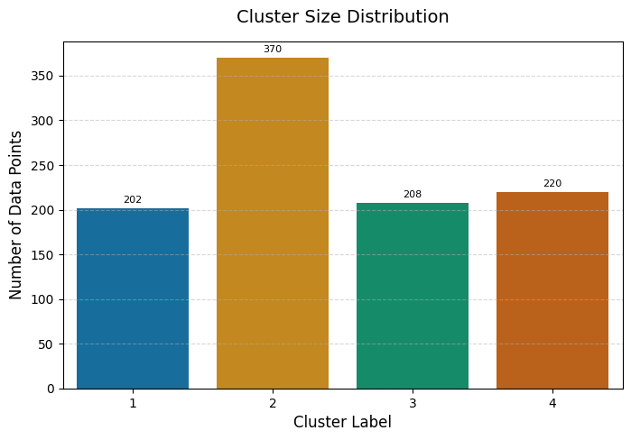

```python
print("Creating cluster size distribution chart to analyze cluster populations...")
# To Do: Create a cluster size distribution chart, and save it into a png file under the 'output' folder.

# count the number of data points in each cluster
cluster_counts = subset['Cluster Label'].value_counts().sort_index()

# bar chart
plt.figure(figsize=(8, 5))
sns.barplot(
    x=cluster_counts.index,
    y=cluster_counts.values,
    palette='colorblind',
)

# labels
plt.title('Cluster Size Distribution', fontsize=14, pad=15)
plt.xlabel('Cluster Label', fontsize=12)
plt.ylabel('Number of Data Points', fontsize=12)
plt.xticks(fontsize=10)
plt.yticks(fontsize=10)
plt.grid(axis='y', linestyle='--', alpha=0.5)

# value labels on top of each bar for easy reading
for i, count in enumerate(cluster_counts.values):
    plt.text(i, count + (max(cluster_counts.values) * 0.01), str(count),
             ha='center', va='bottom', fontsize=8, fontweight='normal')

plt.savefig('output/cluster_size.png', bbox_inches='tight')
```

```
Cluster size distribution visualization display...
```

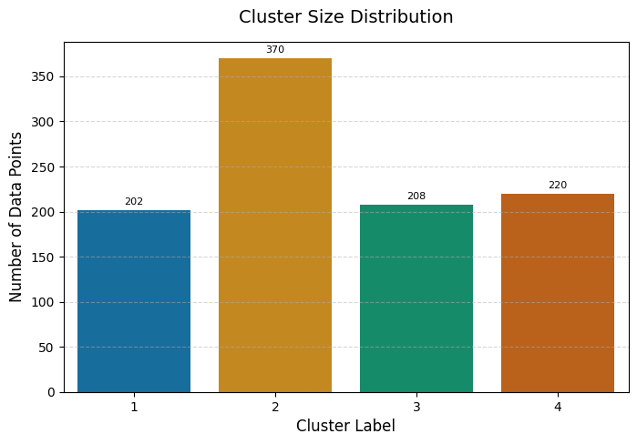

```python
print("Cluster size distribution visualization display...")
# To Do: output the image using the display() function, for example: display(Image(filename="output/cluster_size.png"))
display(Image(filename='output/cluster_size.png'))
```

### Feature Importance Heatmap

*Hints:* A feature importance heatmap highlights the average feature values for each cluster. Save the image as **heatmap.png**. Use **display()** to render the image for html file output. Do not use an html image tag in the markdown, or the image will not print in the html download.

```
Creating feature importance heatmap to show mean feature values by cluster...
```

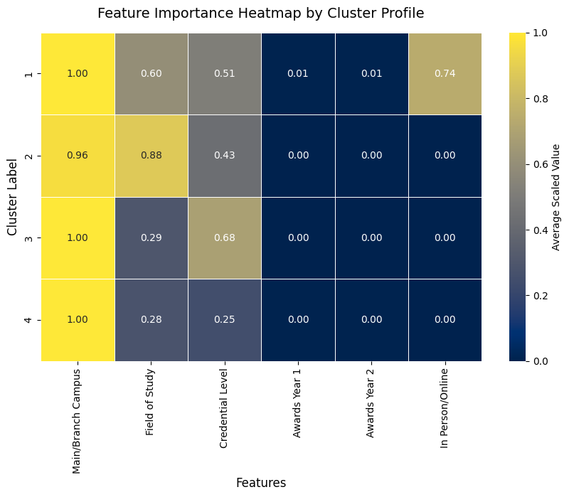

```python
print("Creating feature importance heatmap to show mean feature values by cluster...")
# To Do: Create a feature importance heatmap, and save it into a png file under the 'output' folder.

# calculate average feature values
cluster_profiles = subset.groupby('Cluster Label').mean()

plt.figure(figsize=(10, 6))
sns.heatmap(
    cluster_profiles,
    annot=True,
    cmap='cividis',
    fmt=".2f",
    linewidths=0.5,
    cbar_kws={'label': 'Average Scaled Value'}
)

# labels
plt.title('Feature Importance Heatmap by Cluster Profile', fontsize=14, pad=15)
plt.xlabel('Features', fontsize=12)
plt.ylabel('Cluster Label', fontsize=12)

# 5. Save the image as a PNG file
plt.savefig('output/heatmap.png', bbox_inches='tight')
```

```
Feature important heatmap visualization display...
```

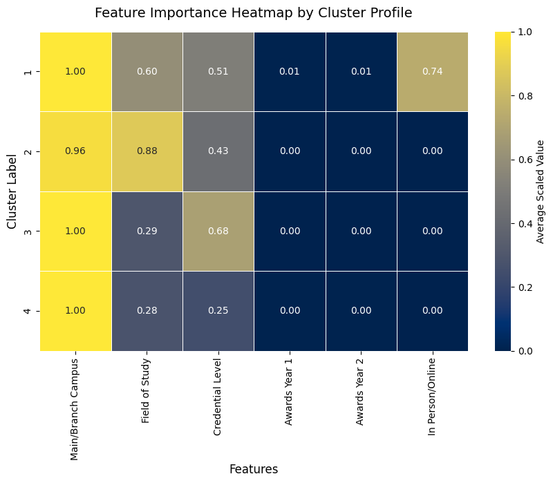

```python
print("Feature important heatmap visualization display...")
# To Do: output the image using the display() function, for example: display(Image(filename="output/heatmap.png"))
display(Image(filename='output/heatmap.png'))
```

### Trend Chart

*Hints:* A trend chart plots trends in a numeric feature across clusters. Save the image as **trend_chart.png**. Use **display()** to render the image for html file output. Do not use an html image tag in the markdown, or the image will not print in the html download.

```
Creating trend chart to analyze a numeric feature across clusters...
```

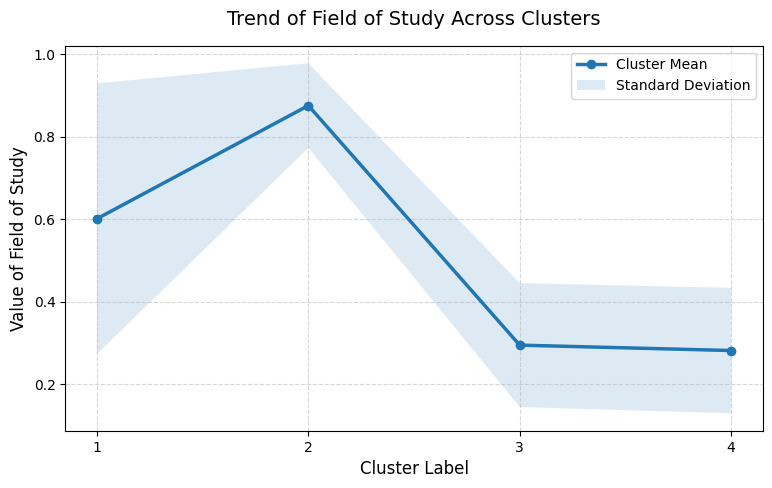

```python
print("Creating trend chart to analyze a numeric feature across clusters...")
# To Do: Create a trend chart to analyze a numeric feature across clusters, and save it into a png file under the 'output' folder.

feature_to_track = 'Field of Study'

# calculate mean and standard error for trend line
trend_data = subset.groupby('Cluster Label')[feature_to_track].agg(['mean', 'std']).reset_index()

# plotting
plt.figure(figsize=(9, 5))
plt.plot(
    trend_data['Cluster Label'].astype(str),
    trend_data['mean'],
    marker='o',
    linewidth=2.5,
    color='#1f77b4',
    label='Cluster Mean'
)

# shaded area to show variability
plt.fill_between(
    trend_data['Cluster Label'].astype(str),
    trend_data['mean'] - trend_data['std'],
    trend_data['mean'] + trend_data['std'],
    alpha=0.15,
    label='Standard Deviation'
)

# labels
plt.title(f'Trend of {feature_to_track} Across Clusters', fontsize=14, pad=15)
plt.xlabel('Cluster Label', fontsize=12)
plt.ylabel(f'Value of {feature_to_track}', fontsize=12)
plt.grid(True, linestyle='--', alpha=0.5)
plt.legend(loc='best')

# 6. Save the image as a PNG file
plt.savefig('output/trend_chart.png', bbox_inches='tight')
```

```
Trend chart visualization display...
```

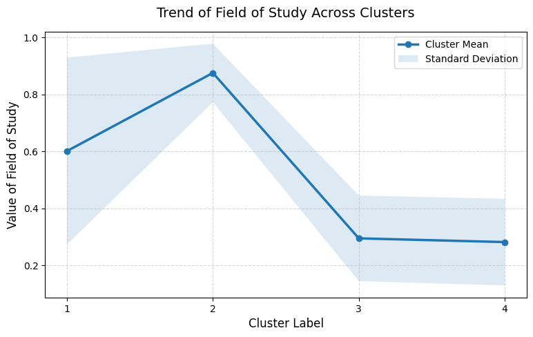

```python
print("Trend chart visualization display...")
# To Do: output the image using the display() function, for example: display(Image(filename="output/trend_chart.png"))
display(Image(filename='output/trend_chart.png'))
```

### Scatter Plot

*Hints:* A scatter plot explores the relationship between two features, grouped by clusters. Save the image as **scatter_plot.png**. Use **display()** to render the image for html file output. Do not use an html image tag in the markdown, or the image will not print in the html download.

```
Creating scatter plot of two features...
```

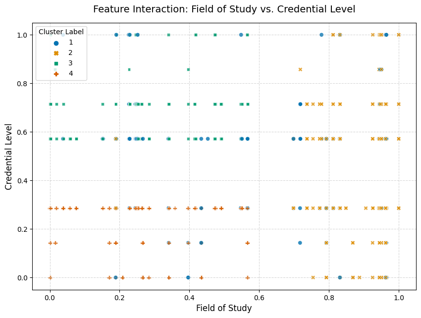

```python
print("Creating scatter plot of two features...")
# To Do: Create a scatter plot of two features, and save it into a png file under the 'output' folder.

feature_x = 'Field of Study'
feature_y = 'Credential Level'

plt.figure(figsize=(10, 7))
sns.scatterplot(
    data=subset,
    x=feature_x,
    y=feature_y,
    hue='Cluster Label',
    style='Cluster Label',
    palette='colorblind',
    alpha=0.8,
)

# labels
plt.title(f'Feature Interaction: {feature_x} vs. {feature_y}', fontsize=14, pad=15)
plt.xlabel(feature_x, fontsize=12)
plt.ylabel(feature_y, fontsize=12)
plt.legend(title='Cluster Label', loc='best', frameon=True)
plt.grid(True, linestyle='--', alpha=0.5)

plt.savefig('output/scatter_plot.png', bbox_inches='tight')
```

```
Scatter plot visualization display...
```

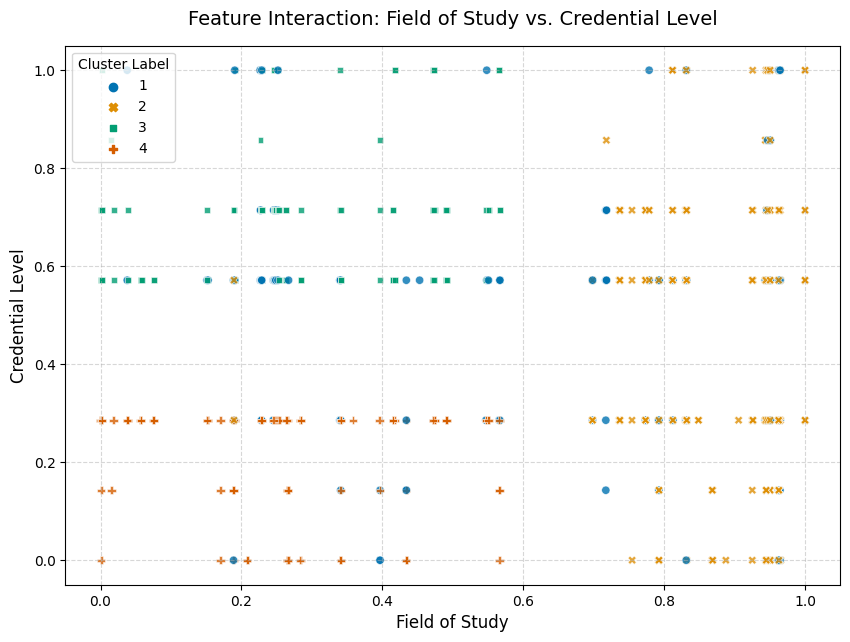

```python
print("Scatter plot visualization display...")
# To Do: output the image using the display() function, for example: display(Image(filename="output/scatter_plot.png"))

display(Image(filename='output/scatter_plot.png'))
```

## Part 2: Reflection

*This part is to be completed in a word document, using the output above to answer the topics.*

### Identify patterns in the data. Consider the following:

- Are there any clear trends, clusters, or outliers visible in your visualizations?
- Are certain variables showing consistent behavior or relationships?
- Are the patterns similar across different visualization types?

### Draw conclusions from the patterns. Consider the following:

- Are your conclusions clearly based on the patterns you observed?
- Are your findings supported by multiple visuals or data points?

### Explain how the visualizations validate your findings. Consider the following:

- Are specific chart elements (e.g., color, scale, labels) helping to highlight your findings?
- Are the insights you found something you could not easily see without the visuals?

### Write a summary of the visualization choices you made. Include the following:

- An explanation of the types of charts you used
- An explanation of the formatting decisions to support visual clarity